# Trabajo Final del Modulo 5 Geoestadística

Silvia Prevettoni

2025-11-11

## Objetivos

Analizar el patrón espacial de los centros y proyectos de centrales de generación de energía renovable en la provincia de Cordoba.

### Base de Datos y sus variables

Esta base de datos contiene 180 registros y 10 variables. Para el objetivo de este estudio, las variables de interés son las siguientes

-Proyecto: Variable de tipo carácter. Detalla el nombre del proyecto.

-Provincia: Variable de tipo carácter. Indica la provincia donde se ubica el proyecto.

-Tecnología: Variable de tipo carácter. Especifica el tipo de energía renovable. Las categorías son: .Biogás .Biomasa .Biomasa de residuos sólidos (BRS) .Eólica .Eólica con Almacenamiento .Hidrógeno Verde (HI) .Pequeño Aprovechamiento Hidroeléctrico (PAH) .Solar .Solar con Almacenamiento

-Latitud: En formato decimal (grados decimales)

-Longitud: En formato decimal (grados decimales)

-Geometría

La segunda base de datos, sobre comunidades indígenas, proviene de la plataforma “Poblaciones” y corresponde al listado oficial publicado por el Instituto Nacional de Asuntos Indígenas (INAI) del Ministerio de Justicia y Derechos Humanos de la Nación. Los datos reflejan la información disponible para el año 2021.

Esta base de datos contiene 12 registros y 28 variables. Las variables de interés son las siguientes:

-Nombre: Variable de tipo carácter. Detalla el nombre de la comunidad.

-Provincia: Variable de tipo carácter. Indica la provincia donde se ubica la comunidad.

-Latitud: En formato DMS (grados, minutos, segundos)

-Longitud: En formato DMS ((grados, minutos, segundos)

## Enfoque metodológico

El objetivo propuesto se analizará mediante análisis de patrones de puntos, ya que interesa la localización de las obras y proyectos de energía renovable. El estudio se centrará en: La configuración espacial de los proyectos, evaluando:

-Su intensidad o densidad (propiedades de primer orden)

-Su estructura espacial, que indica interacciones de atracción o repulsión entre puntos (propiedades de segundo orden)

-La interacción con comunidades indígenas, analizando la correlación espacial entre la ubicación de los proyectos y las comunidades.

## Exploración de datos

### Preparación del ambiente de trabajo

```
## replacing null geometries with empty geometries
## Simple feature collection with 180 features and 9 fields (with 44 geometries empty)
## Geometry type: POINT
## Dimension:     XY
## Bounding box:  xmin: -72.24658 ymin: -51.51479 xmax: -54.43767 ymax: -23.94516
## Geodetic CRS:  WGS 84
```

```
##       ID              PROYECTO          PROVINCIA          TECNOLOGIA
##  Length:180         Length:180         Length:180         Length:180
##  Class :character   Class :character   Class :character   Class :character
##  Mode  :character   Mode  :character   Mode  :character   Mode  :character
##
##
##
##
##     RONDA             POTENCIA_M        LATITUD          LONGITUD
##  Length:180         Min.   :  0.52   Min.   :-51.51   Min.   :-72.25
##  Class :character   1st Qu.:  2.84   1st Qu.:-34.11   1st Qu.:-66.05
##  Mode  :character   Median : 12.90   Median :-32.28   Median :-63.20
##                     Mean   : 55.71   Mean   :-32.13   Mean   :-63.09
##                     3rd Qu.: 26.25   3rd Qu.:-28.32   3rd Qu.:-60.41
##                     Max.   :950.00   Max.   :-23.95   Max.   :-54.44
##                     NA's   :140      NA's   :44       NA's   :44
##     ESTADO                   geometry
##  Length:180         POINT        :180
##  Class :character   epsg:4326    :  0
##  Mode  :character   +proj=long...:  0
##
##
##
##
```

```
## Simple feature collection with 1 feature and 13 fields
## Geometry type: MULTIPOLYGON
## Dimension:     XY
## Bounding box:  xmin: -73.56054 ymin: -55.19257 xmax: -53.63745 ymax: -21.78086
## Geodetic CRS:  WGS 84
##   place_id
## 1 18621440
##                                                                 licence
## 1 Data © OpenStreetMap contributors, ODbL 1.0. http://osm.org/copyright
##   osm_type osm_id         lat         lon    class           type place_rank
## 1 relation 286393 -34.9964963 -64.9672817 boundary administrative          4
##   importance addresstype      name display_name                       geometry
## 1  0.8703716     country Argentina    Argentina MULTIPOLYGON (((-73.56054 -...
```

### Visualizamos en el mapa la cantidad de proyectos y obras centrales por provincia, junto con sus tecnologías.

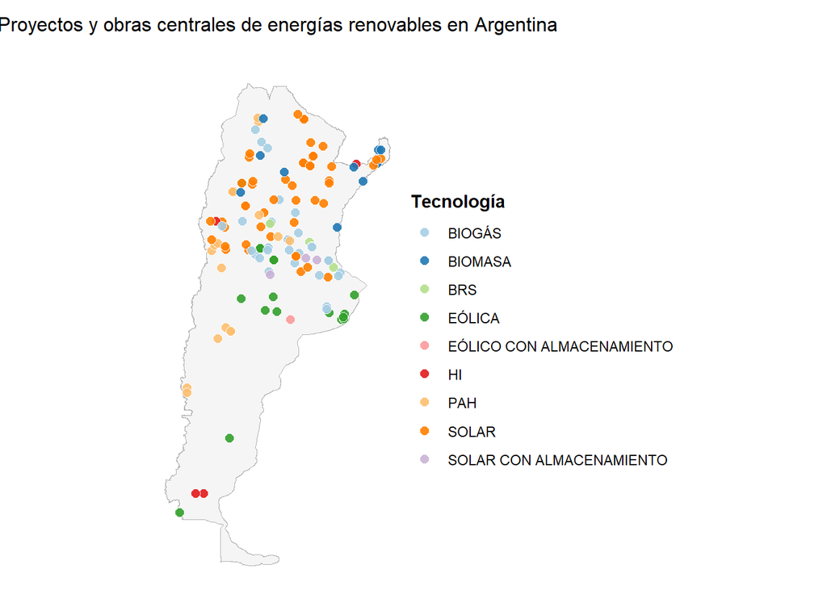

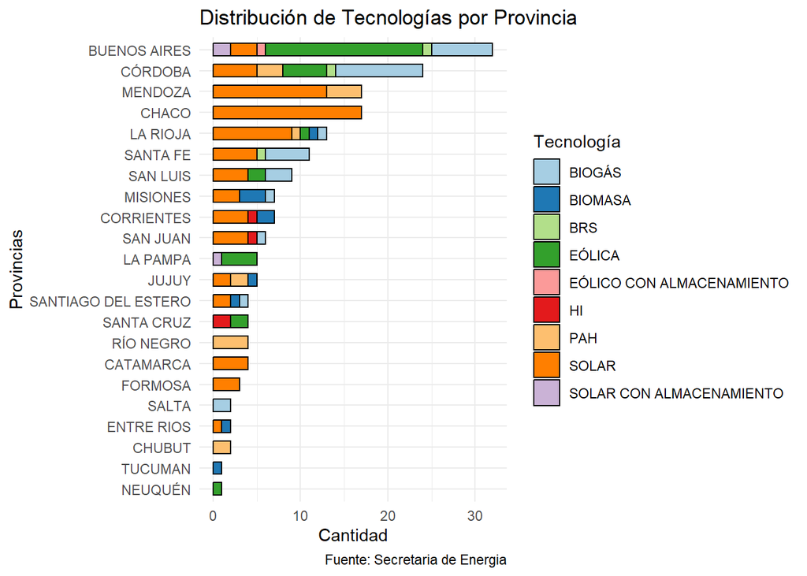

En el gráfico observamos que la mayoría de las obras y proyectos se concentran en la provincia de Buenos Aires, seguida por Córdoba y Mendoza. Este análisis, se focalizará en la provincia de Córdoba por ser la segunda en cantidad y variedad de tecnologías: solar, pequeño aprovechamiento hidroeléctrico (PAH), eólica, biomasa de residuos sólidos (BRS) y biogás.

Filtramos los datos de la provincia de Córdoba y nos quedamos con las variables de nuestro interés.

Lo vemos en un mapa interactivo

[interactive chart not shown]

Incorporamos la base de datos de comunidades indígenas de Córdoba para georreferenciar la ubicación de las distintas comunidades.

El formato de longitud y latitud del dataset de comunidades se encuentran en coordenadas cuyo formato está en grados, minutos y segundos (DMS) con símbolos especiales, por lo tanto tengo que utilizar una función para convertirlas de DMS a decimal.

Ahora ya lo tenemos en formato decimal,

Veamos su estructura;

```
##        Id           Nombre             Pueblo          Código.de.provincia
##  Min.   :14001   Length:12          Length:12          Min.   :14
##  1st Qu.:14004   Class :character   Class :character   1st Qu.:14
##  Median :14006   Mode  :character   Mode  :character   Median :14
##  Mean   :14007                                         Mean   :14
##  3rd Qu.:14009                                         3rd Qu.:14
##  Max.   :14016                                         Max.   :14
##   Provincia         Código.de.departamento Departamento
##  Length:12          Min.   :14.00          Length:12
##  Class :character   1st Qu.:24.50          Class :character
##  Mode  :character   Median :31.50          Mode  :character
##                     Mean   :47.83
##                     3rd Qu.:91.00
##                     Max.   :98.00
##  Código.de.localidad  Localidad         Barrio.o.paraje        Zona
##  Min.   : 10.0       Length:12          Length:12          Length:12
##  1st Qu.: 10.0       Class :character   Class :character   Class :character
##  Median :140.0       Mode  :character   Mode  :character   Mode  :character
##  Mean   :102.5
##  3rd Qu.:170.0
##  Max.   :190.0
##    Latitud            Longitud         Estado.de.la.personería.jurídica
##  Length:12          Length:12          Length:12
##  Class :character   Class :character   Class :character
##  Mode  :character   Mode  :character   Mode  :character
##
##
##
##  Tipo.de.inscripción.de.personería Número.de.inscripción.de.personería
##  Length:12                         Length:12
##  Class :character                  Class :character
##  Mode  :character                  Mode  :character
##
##
##
##  Fecha.de.inscripción.de.personería Registro.de.inscripción.de.personería
##  Length:12                          Length:12
##  Class :character                   Class :character
##  Mode  :character                   Mode  :character
##
```

[output cut: 15 more lines]

```
##                                Max.   :14
##  Código.de.departamentos.comuna Nombre.de.departamentos.comuna
##  Min.   :14014                  Length:12
##  1st Qu.:14024                  Class :character
##  Median :14032                  Mode  :character
##  Mean   :14048
##  3rd Qu.:14091
##  Max.   :14098
##  Código.de.radio     Nombre.de.radio          geometry
##  Min.   :140145204   Mode:logical    POINT        :12
##  1st Qu.:140247252   NA's:12         epsg:5347    : 0
##  Median :140315408                   +proj=tmer...: 0
##  Mean   :140480538
##  3rd Qu.:140910206
##  Max.   :140981703
```

Manipulamos los datos de energías renovables para convertir la tabla a puntos transformándola a faja 5347

Visualizamos todos los datos

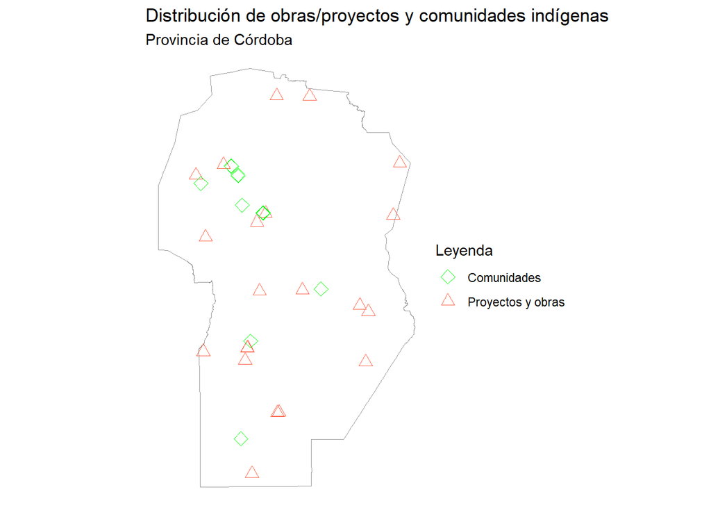

Aquí vemos la localización de los proyectos de energías renovables y las comunidades indígenas.

Preparo los datos para el análisis de patrones de puntos.

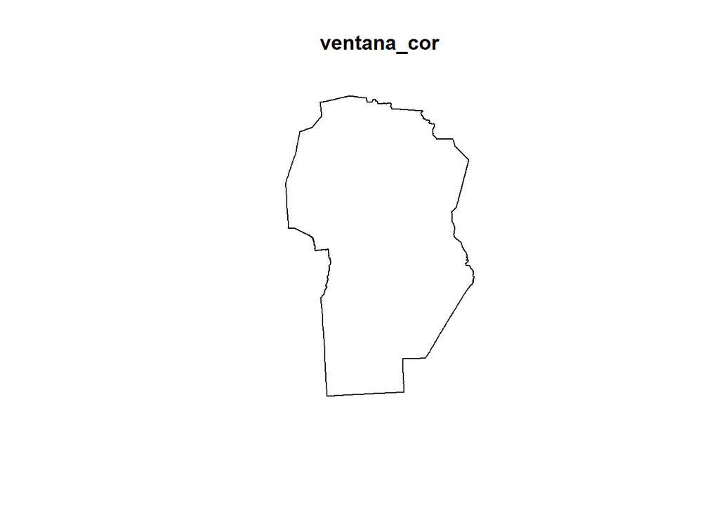

Al tener puntos duplicados, los eliminamos con la funcion rjitter.

¿Existen aún los puntos duplicados?

```
##
## Existen puntos duplicados: FALSE
```

Lo vemos en el mapa,

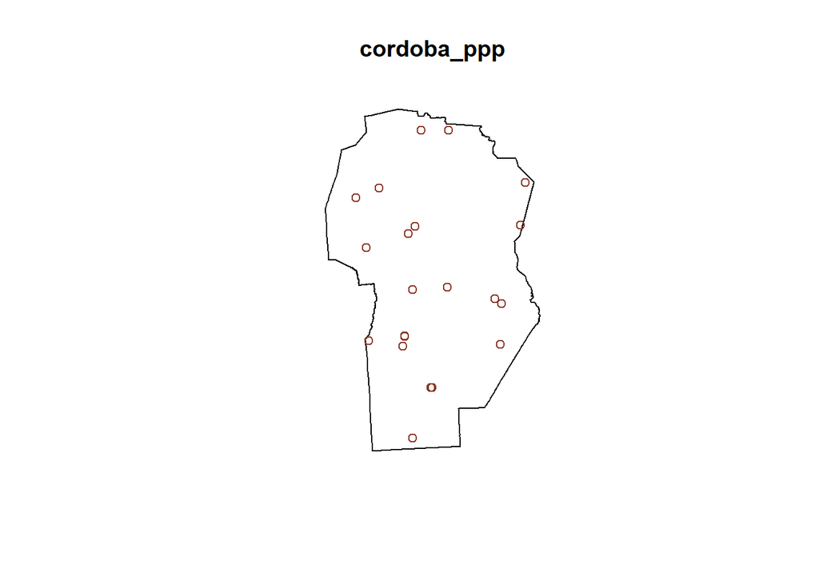

```
## Planar point pattern:  23 points
## Average intensity 0.0000000001390488 points per square Meter
##
## Coordinates are given to 9 decimal places
##
## Window: polygonal boundary
## single connected closed polygon with 11605 vertices
## enclosing rectangle: [4948628, 5334244] x [6113674, 6729359] Meter
##                      (385600 x 615700 Meter)
## Window area = 165410000000 square Meter
## Unit of length: 1 Meter
## Fraction of frame area: 0.697
```

### Estadísticas de resumen de primer orden (globales)

### Intensidad del patrón de puntos

### ¿Cuál es la intensidad de los puntos?”

```
## Intensidad de obras/proyectos por metro cuadrado: 0.0000000001390488
```

```
## Intensidad de obras/proyectos por kilómetro cuadrado: 0,000139
```

Podemos confirmar que se trata de un patrón de puntos homogéneo y aleatorio; es decir, ¿la intensidad es constante en el espacio? ¿Es estacionaria?

### Intensidad por cuadrantes

Se subdivide la ventana en sectores que cubran la totalidad del área de interés para calcular la intensidad en cada uno de ellos.

Optamos por la teselación cuadricular en lugar de la hexagonal debido a sus menores requisitos computacionales.

```
## tile
## Tile row 1, col 1 Tile row 1, col 2 Tile row 1, col 3 Tile row 1, col 4
##                 0                 0                 2                 0
## Tile row 1, col 5 Tile row 2, col 1 Tile row 2, col 2 Tile row 2, col 3
##                 0                 1                 2                 1
## Tile row 2, col 4 Tile row 2, col 5 Tile row 3, col 1 Tile row 3, col 2
##                 0                 2                 1                 0
## Tile row 3, col 3 Tile row 3, col 4 Tile row 3, col 5 Tile row 4, col 1
##                 2                 2                 1                 0
## Tile row 4, col 2 Tile row 4, col 3 Tile row 4, col 4 Tile row 4, col 5
##                 5                 0                 0                 1
## Tile row 5, col 2 Tile row 5, col 3 Tile row 5, col 4 Tile row 5, col 5
##                 0                 3                 0                 0
```

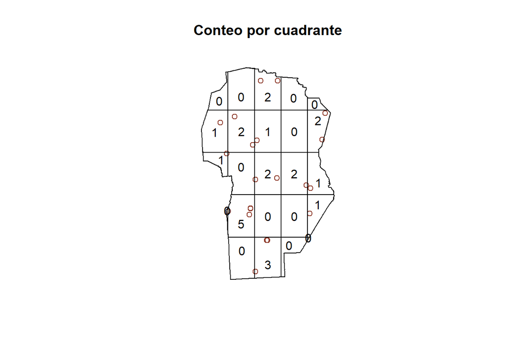

### Formulamos el test de hipotesis

- Hipótesis nula (H0): la intensidad es homogénea y la distribución de casos en los cuadrantes responde a una distribución de Poisson (CSR).
- Hipótesis alternativa (H1): la intensidad no es homogénea.

El nivel de significacion es de del 5% o 0.05.

Los cuadrantes no tienen la misma superficie por lo tanto utilizamos el test de Montecarlo.

```
##
##  Conditional Monte Carlo test of CSR using quadrat counts
##  Test statistic: Pearson X2 statistic
##
## data:  cordoba_ppp
## X2 = 27.002, p-value = 0.3616
## alternative hypothesis: two.sided
##
## Quadrats: 24 tiles (irregular windows)
```

Según el test, no debemos rechazar la hipótesis nula (p-value > 0.05). Por lo tanto, el patrón es consistente con un proceso de Aleatoriedad Espacial Completa (CSR), que corresponde a un proceso de Poisson homogéneo.

Graficamos el resultado del test utilizando pocos cuadrantes para facilitar su lectura, obteniendo el conteo real, el esperado y los residuos;

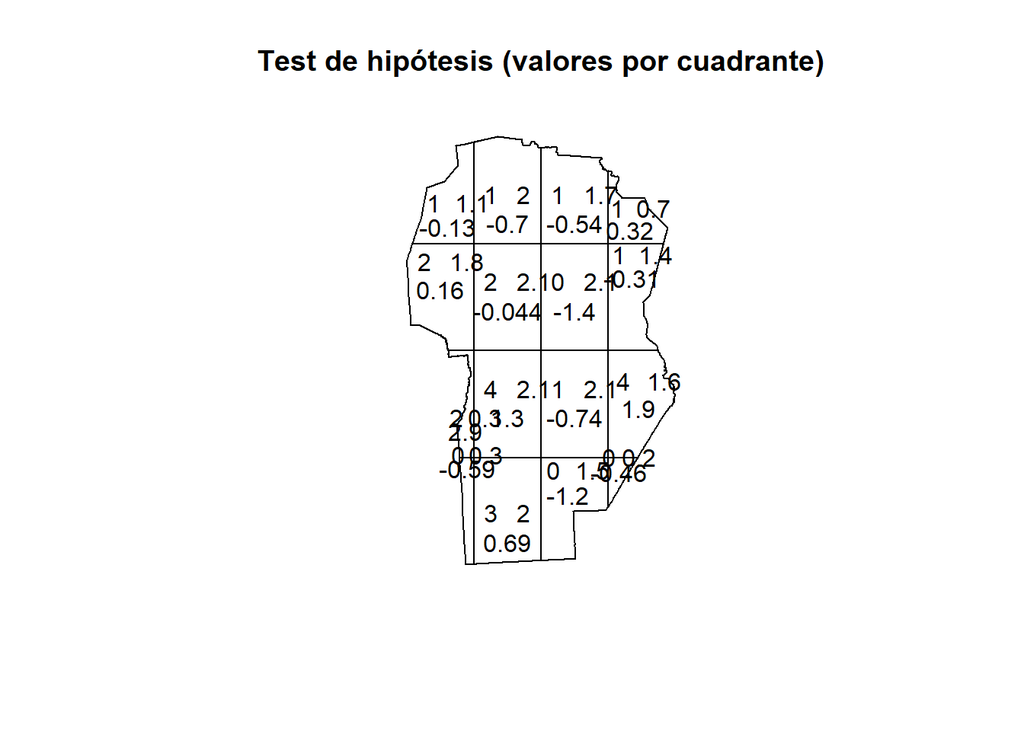

### Modelando la densidad mediante una función kernel

La intensidad mediante Kernel se estima típicamente cuando el proceso puntual es heterogéneo. Si bien este no es nuestro caso, igualmente realizamos el cálculo para confirmar que la intensidad es efectivamente plana y uniforme.

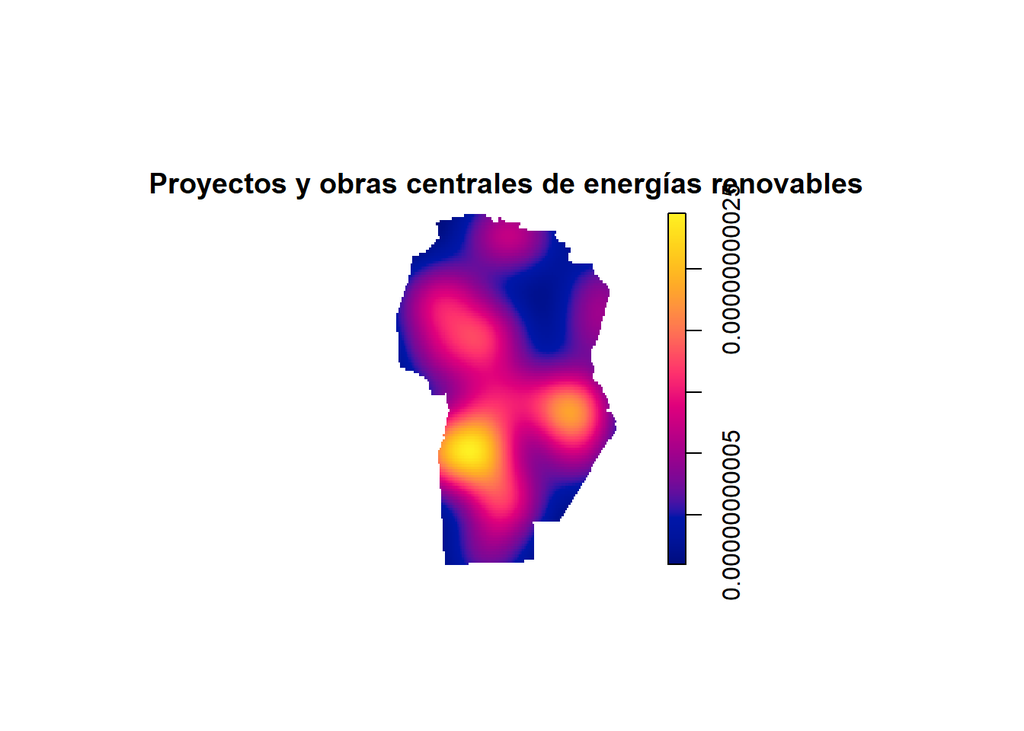

```
## [1] "im"
```

```
## [1] 48202.05
```

El mapa de kernel permite visualizar fácilmente la densidad de puntos. El parámetro sigma representa el radio de suavizado, que en este caso es de 48202 unidades.

Validación visual de la homogeneidad

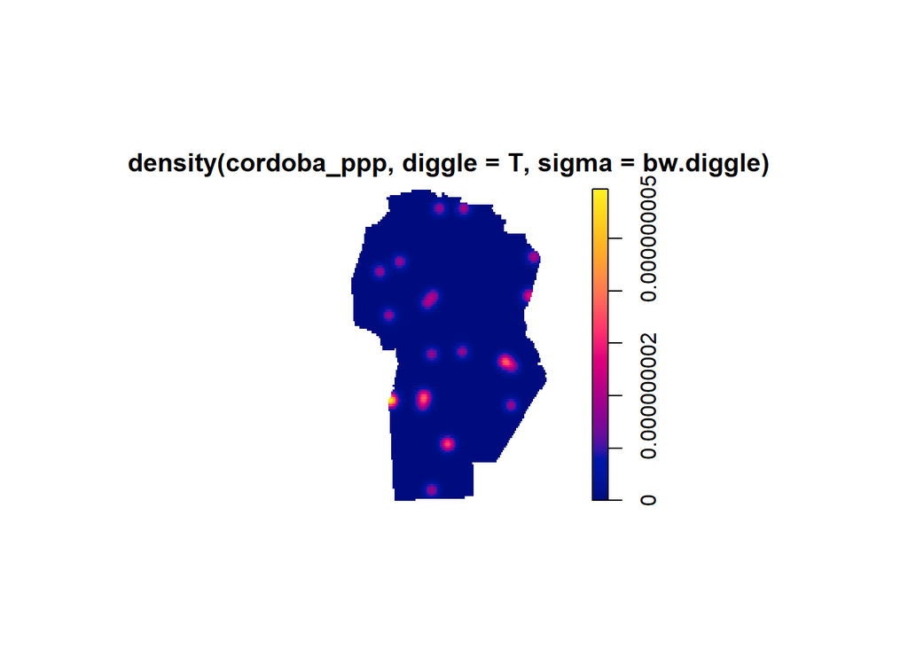

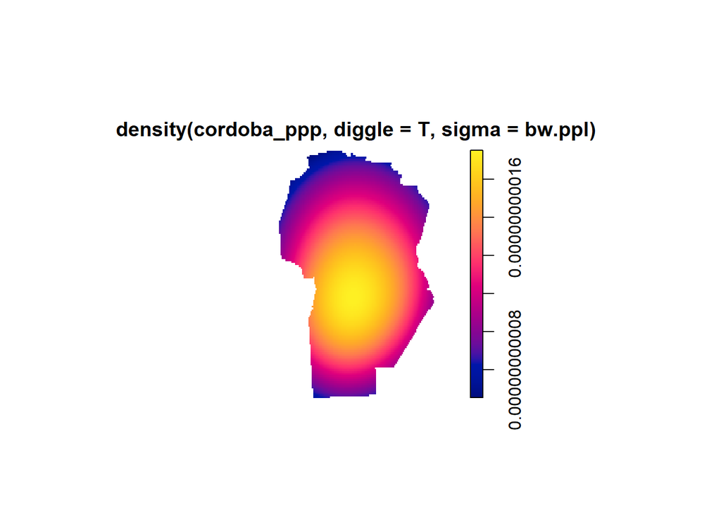

## Estadísticas de resumen de segundo orden (locales)

Vamos a realizar las pruebas de aleatoriedad basadas en distancias para evaluar el tipo de patrón en términos de distancias y escalas.

### Función K

Este estudio evalúa si existe agrupamiento, dispersión o distribución aleatoria de las obras y proyectos en el espacio, determinando también las distancias críticas de interacción

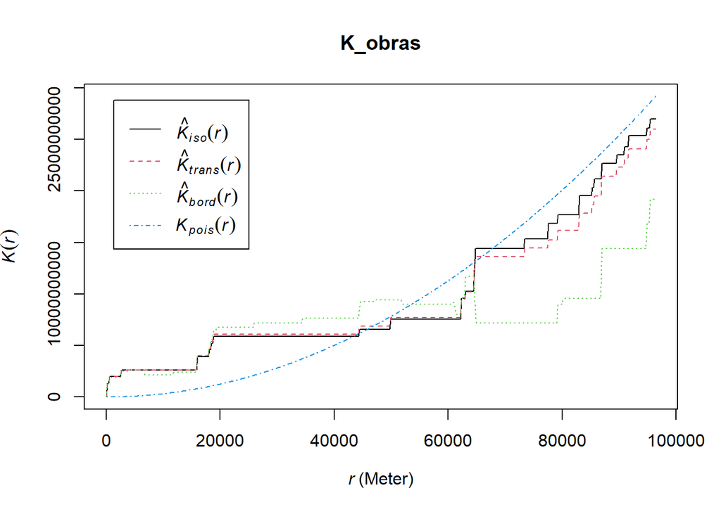

La contrastamos con la banda de confianza mediante simulaciones de Monte Carlo generando múltiples patrones aleatorios bajo la hipótesis nula de completa aleatoriedad (CSR). El envelope representa el rango entre los valores mínimos y máximos en cada distancia r.

```
## Generating 20 simulations of CSR  ...
## 1, 2, 3, 4, 5, 6, 7, 8, 9, 10, 11, 12, 13, 14, 15, 16, 17, 18, 19,
## 20.
##
## Done.
```

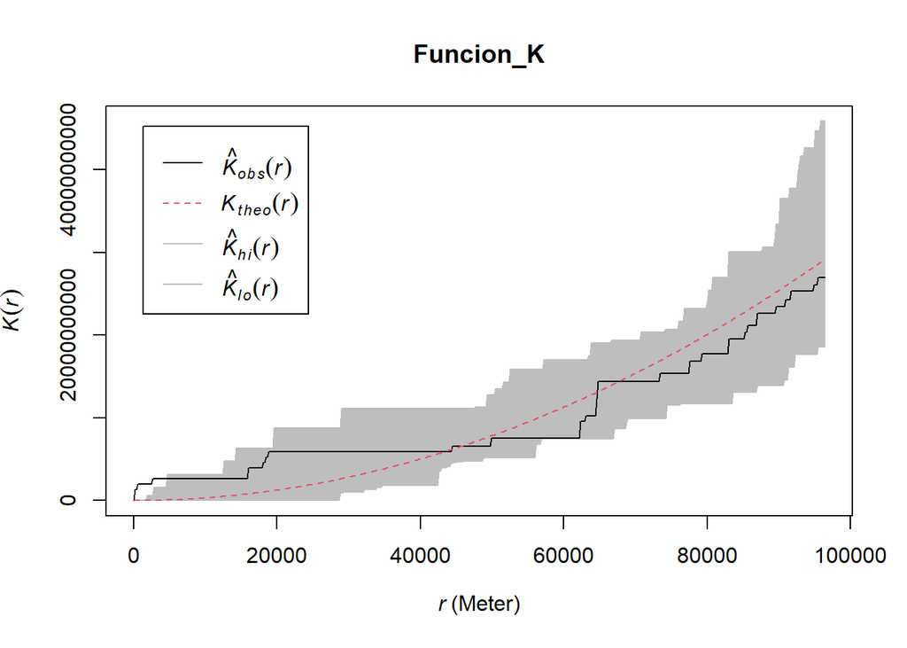

Los proyectos de energía renovable tienden a agruparse a distancias cortas, compartiendo zonas de recursos e infraestructura común, mientras que a distancias largas se dispersan para evitar la saturación regional y buscar diferentes zonas de recursos.

### Función L de Besag

```
## Generating 20 simulations of CSR  ...
## 1, 2, 3, 4, 5, 6, 7, 8, 9, 10, 11, 12, 13, 14, 15, 16, 17, 18, 19,
## 20.
##
## Done.
```

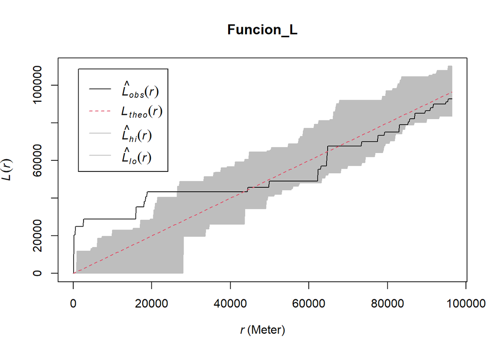

### Función G

¿Qué tan cerca está mi vecino más cercano?

Vamos a ver el patrón que nos sugiere la funcion G, función que nos permite ver la distancia al vecino mas cercano midiendo la distribución de las distancias desde cada punto hasta su vecino más cercano.

```
## Generating 20 simulations of CSR  ...
## 1, 2, 3, 4, 5, 6, 7, 8, 9, 10, 11, 12, 13, 14, 15, 16, 17, 18, 19,
## 20.
##
## Done.
```

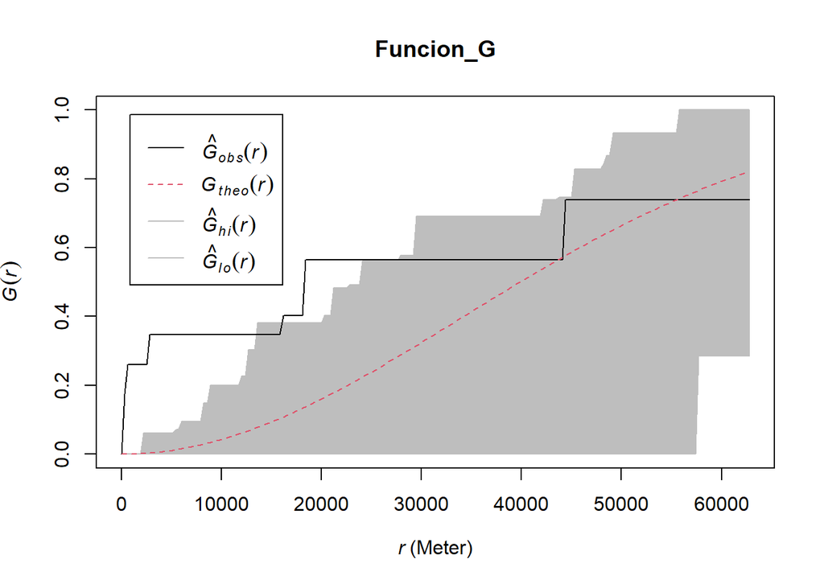

Aquí vemos que la Gobs(r) es mayor que Gtheo(r), por lo tanto indica agregación. Los puntos tienen vecinos más cercanos de lo que esperaría por azar; o sea, las distancias al vecino más cercano en el patrón son más cortas en comparación con un proceso de Poisson homogéneo.

### Función F

¿Qué tan lejos estoy del punto más cercano? Esta función mide el espacio vacío o distancia al próximo proyecto desde un punto fijo del espacio al punto más cercano del patrón.

```
## Generating 20 simulations of CSR  ...
## 1, 2, 3, 4, 5, 6, 7, 8, 9, 10, 11, 12, 13, 14, 15, 16, 17, 18, 19,
## 20.
##
## Done.
```

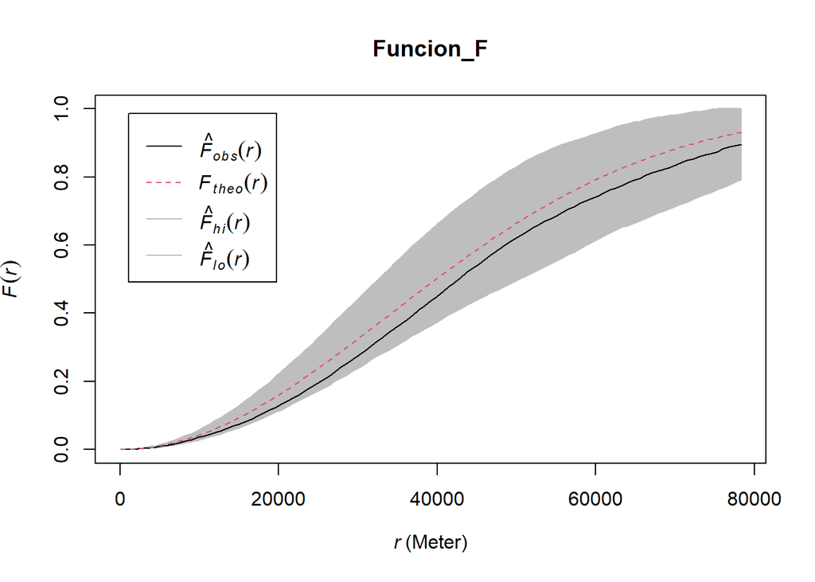

Aquí vemos que la Fobs está debajo de la línea Ftheo, indicando agregación; o sea, menor porcentaje de distancias cortas al vecino más cercano.

### Función J

Combina las funciones G y F.

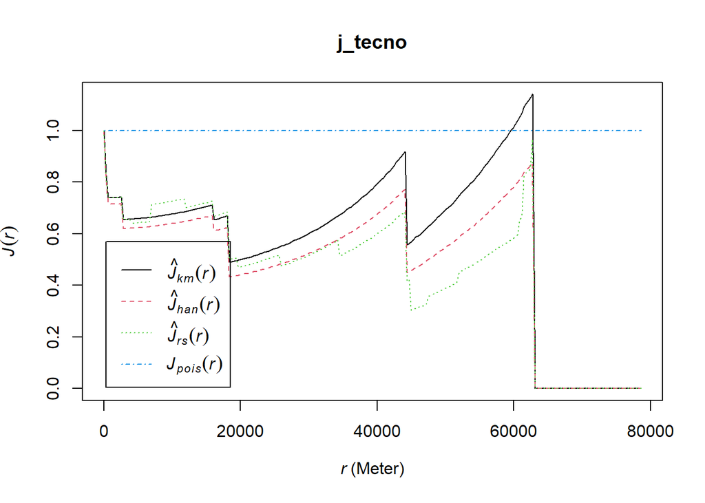

```
## Generating 20 simulations of CSR  ...
## 1, 2, 3, 4, 5, 6, 7, 8, 9, 10, 11, 12, 13, 14, 15, 16, 17, 18, 19,
## 20.
##
## Done.
```

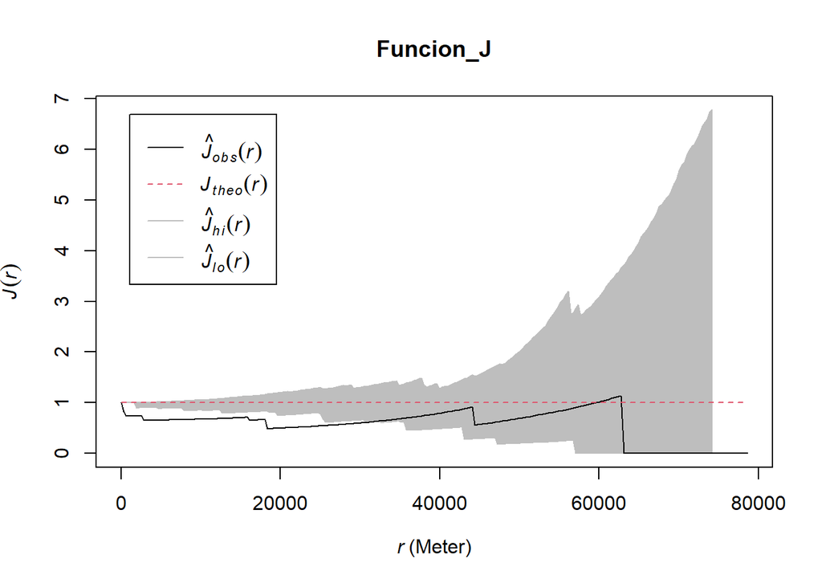

Visualicemos todas las funciones juntas.

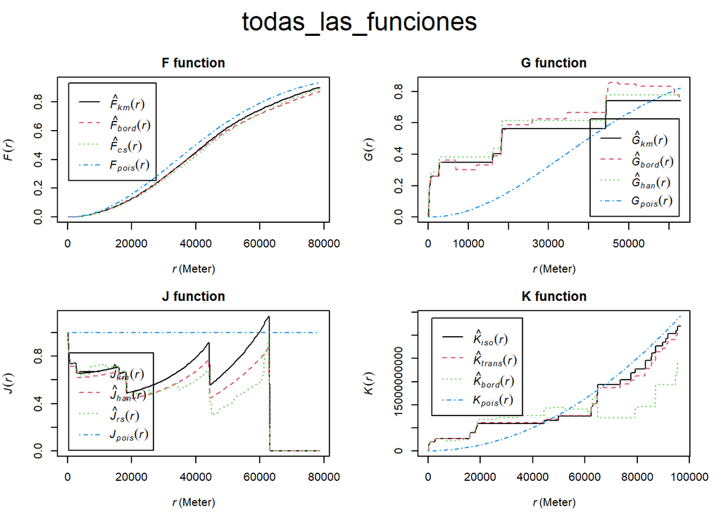

Vemos la funciones a escala.

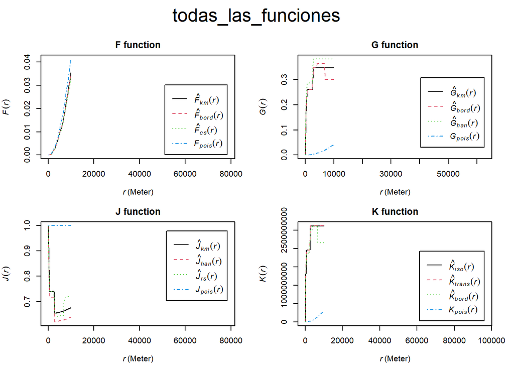

### Interacción entre patrones marcados

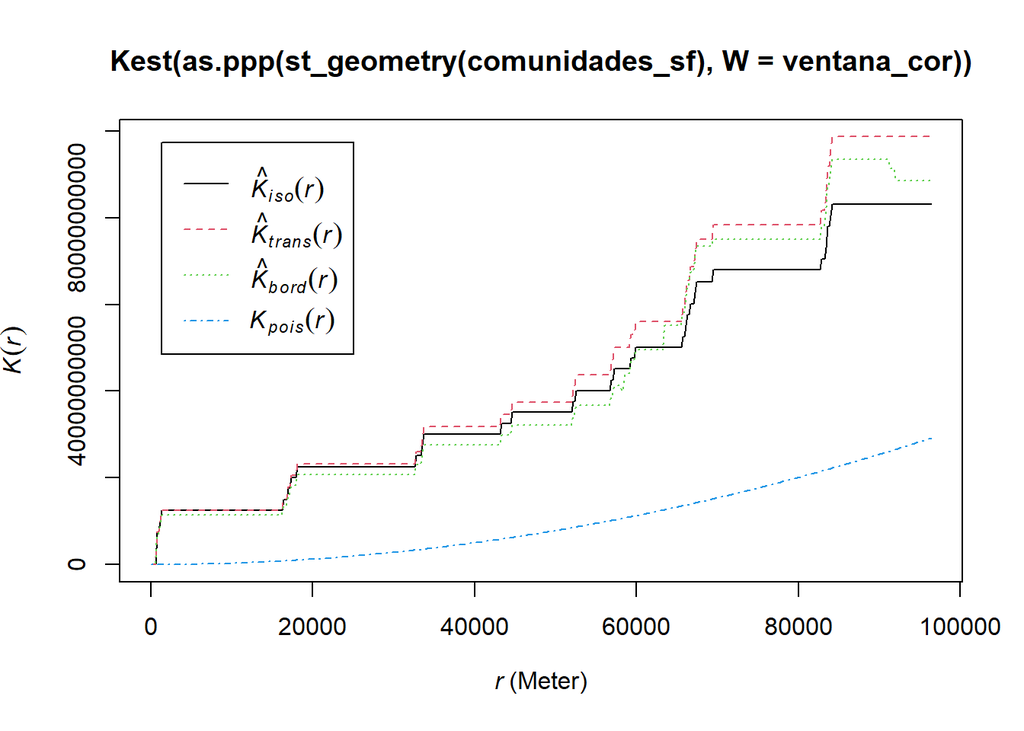

### Función K multimarca

Interpreto el gráfico de K cruzada que muestra la relación espacial entre comunidades y energías. Podemos observar los diferentes métodos para corregir los efectos borde, siendo la Kiso el más confiable.

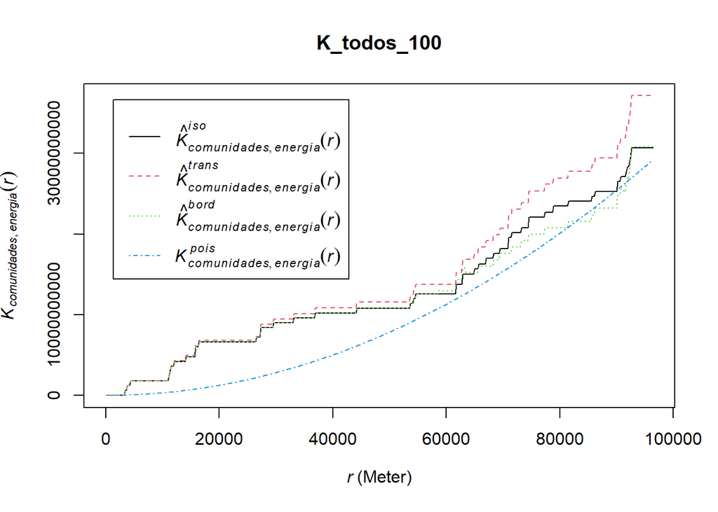

Puedo observar que la línea negra Kiso (estimador corregido por isotropía) se encuentra por encima de la línea Kpois (la línea de Poisson), por lo tanto, las comunidades y los proyectos/obras de energía están más cerca de lo esperado por azar

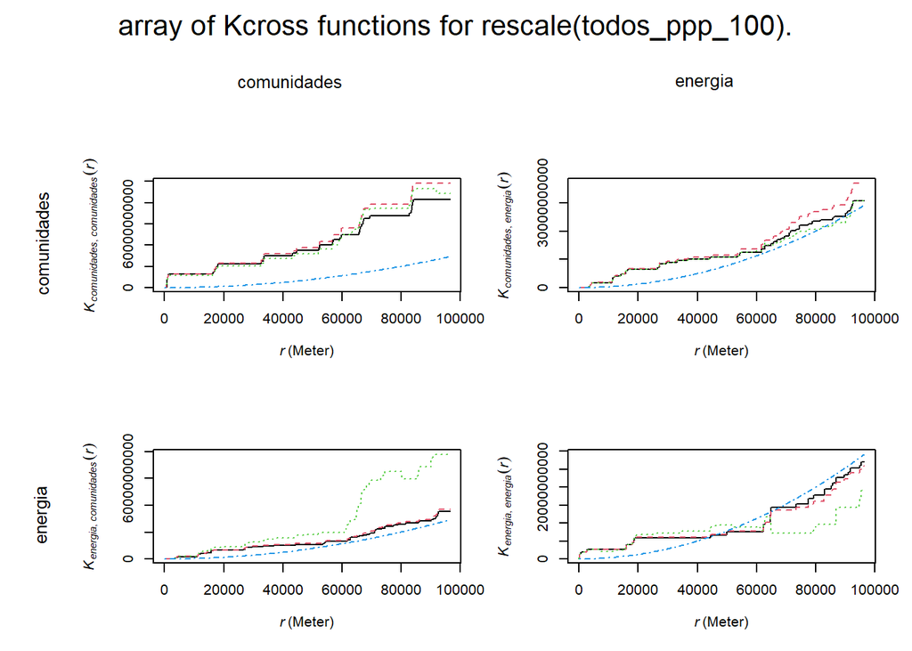

## Conclusión

De acuerdo con el análisis de estadísticas de resumen de primer orden, se determinó que la intensidad de las obras y proyectos es de 0.000139 por km², lo que sugiere un patrón espacial homogéneo.

El test de hipótesis realizado mediante simulación de Monte Carlo con un nivel de significancia de 0.05, permite afirmar que el patrón observado es consistente con un Proceso de Poisson Homogéneo, es decir, un proceso de aleatoriedad espacial completa.